# Rmarkdown: Climate change and tuberculosis drive non-adaptive shifts in gut microbiota of wild meerkats

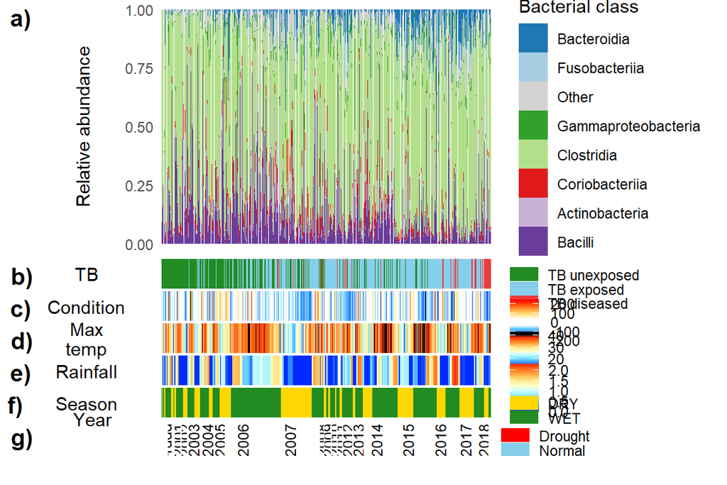

```r
plot_TB_sample<-ggplot(class_per_sample, aes(y = 1, x = reorder(Sample, SampleDate), fill = TB_stage))+
  geom_tile()+
  theme_void()+
scale_fill_manual(values = c( "forestgreen", "skyblue","brown2"))+
  theme(axis.title.y = element_text(angle = 0))+
  ylab("TB")+
  theme(legend.position="right", legend.direction="vertical",
       legend.justification = c("left", "top"),
        legend.key.height = unit(0.3, 'cm'),
        legend.title=element_blank())


# temp max

pal_dichromat<-dichromat::colorschemes$BluetoOrange.12

pal_dichromat[13]<-"black"
pal_dichromat[14]<-"black"


plot_temp1<-ggplot(class_per_sample, aes(y = 1, x = reorder(Sample, SampleDate), fill = Temp_max))+geom_tile()+
  theme_void()+
 scale_fill_gradientn(colours = pal_dichromat)+
  theme(legend.position="right", legend.direction="vertical",
         legend.justification = c("left", "top"),
        legend.key.height = unit(0.15, 'cm'),
        legend.title=element_blank()) +
  theme(axis.title.y = element_text(angle = 0))+
  ylab(" Max \ntemp")

## season

plot_season<-ggplot(class_per_sample, aes(y = 1, x = reorder(Sample, SampleDate), fill = Season))+
  geom_tile()+
  theme_void()+
  scale_fill_manual(values = c("gold", "forestgreen"))+
  theme(legend.position="right", legend.direction="vertical",
        legend.justification = c("left", "top"),
        legend.key.height = unit(0.1, 'cm'),
        legend.title=element_blank())+
   theme(axis.title.y = element_text(angle = 0))+
  ylab("Season")


# year

year_names <- c(
                    `1997` = "",
                    `1998` = "",
                    `1999` = "1999",
                    `2000` = "",
                    `2001` = "2001",
                    `2002` = "2002",
                    `2003` = "2003",
                    `2004` = "2004",
                    `2005` = "2005",
                    `2006` = "2006",
                    `2007` = "2007",
                    `2008` = "2008",
                    `2009` = "2009",
                    `2010` = "2010",
                    `2011` = "2011",
                    `2012` = "2012",
                    `2013` = "2013",
                    `2014` = "2014",
                    `2015` = "2015",
                    `2016` = "2016",
                    `2017` = "2017",
                    `2018` = "2018",
                    `2019` = "")


# 13 x 6

# ####methods
# ####methods
# ####methods
# ####methods

drought_years<- c(1997, 1998, 2000, 2006, 2013, 2014, 2015, 2017, 2018)

class_per_sample$Drought<-ifelse(class_per_sample$Year %in% drought_years, "Drought", "Normal")

drought_cols<- c("red", "red", "skyblue", "red", "skyblue", # 1997 - 2001
                 "skyblue","skyblue","skyblue","skyblue", "red", # 2002 - 2006
                 "skyblue","skyblue","skyblue","skyblue","skyblue", # 2007 - 2011
                 "red", "skyblue", "red", "red", "skyblue", # 2012 - 2016
                 "red", "red" , "skyblue" ) # 2017 - 2019




plot_year<-ggplot(class_per_sample, aes(y = 1, x = reorder(Sample, SampleDate), fill = Drought))+
  geom_tile()+
  theme_void()+
 # scale_fill_viridis(discrete = F)+
  scale_fill_manual(values = c("red", "skyblue"))+
  facet_grid(~Year, scales = "free", space = "free_x",switch = "x", labeller = as_labeller(year_names))+

  theme(panel.spacing = unit(0.07, "lines"),
         strip.background = element_blank(),
         strip.placement = "outside",
         strip.text.x = element_text(angle = 90, hjust = 0.5)) +

   xlab("")+
    theme(axis.title.y = element_text(angle = 0, hjust = ))+
  ylab("Year          ")+
  theme(axis.title.x = element_text(colour = "black"))+
  theme(plot.margin=unit(c(0,2.8,0.2,1.55),"cm")) +
    theme(legend.position="right", legend.direction="vertical",
        legend.justification = c("left", "top"),
        legend.key.height = unit(0.2, 'cm'),
        legend.title=element_blank())



# rainfall

plot_rainfall<-ggplot(class_per_sample, aes(y = 1, x = reorder(Sample, SampleDate), fill = log10(sum_rainfall_month+1)))+geom_tile()+
  theme_void()+
 scale_fill_gradientn(colours = pal_dichromat[1:12])+
   theme(legend.position="right", legend.direction="vertical",
        legend.justification = c("left", "top"),
        legend.key.height = unit(0.2, 'cm'),
        legend.title=element_blank())+
   theme(axis.title.y = element_text(angle = 0))+
  ylab("Rainfall")

## body condition

#scales::show_col(pal_dichromat_cond)

pal_dichromat_cond<-c("black", "black", "black", pal_dichromat[1:12])

pal_dichromat_cond[8]<-"white"
pal_dichromat_cond[9]<-"white"
pal_dichromat_cond[10]<-"white"

pal_dichromat_cond[16]<-"red"

plot_condition<-ggplot(class_per_sample, aes(y = 1, x = reorder(Sample, SampleDate), fill = Condition_weight))+
  geom_tile()+
  theme_void()+
 scale_fill_gradientn(colours = pal_dichromat_cond)+
   theme(legend.position="right", legend.direction="vertical",
        legend.justification = c("left", "top"),
        legend.key.height = unit(0.2, 'cm'),
        legend.title=element_blank())+
   theme(axis.title.y = element_text(angle = 0))+
  ylab("Condition")


## without storage


sup_figabc<-ggarrange(plot_per_sample, plot_TB_sample, plot_condition, plot_temp1, plot_rainfall, plot_season, ncol = 1, align = "v", heights = c(8,1,1, 1,  1,1, 1, 1.5), labels= c("a)", "b)", "c)", "d)", "e)", "f)"))

ggarrange(sup_figabc, plot_year, ncol = 1, heights = c(7,1.1), labels = c(NA, "g)"))
```

```r
# fig 2

#ggsave("Figures/Fig2.pdf")
# Saving 16.4 x 7.97 in image
```

This chunk took 0.99 minutes

# 5 Fig. S2: Storage, time of day, and social group per sample

```r
# social group

group_freq<-data.frame(table(class_per_sample$GroupAtSampling))

group_freq<-group_freq %>% arrange(-Freq)
head(group_freq, 10)
```

|  | Var1 | Freq |
| --- | --- | --- |
| 1 | Van Helsing | 16377 |
| 2 | Vivian | 14008 |
| 3 | Baobab | 12772 |
| 4 | Commandos | 10506 |
| 5 | Whiskers | 9579 |
| 6 | Zulus | 6592 |
| 7 | Ewoks | 6386 |
| 8 | Zappa | 6283 |
| 9 | Rascals | 5665 |
| 10 | Lazuli | 4429 |

```r
top_groups<-group_freq$Var1[1:15]

class_per_sample$GroupAtSampling_plot<-ifelse(class_per_sample$GroupAtSampling %in% top_groups, as.character(class_per_sample$GroupAtSampling), "Other")

mypal =     pal_lancet("lanonc", alpha = 1)(7)
mypal5<- pal_rickandmorty("schwifty")(8)
mypal6<-brewer.pal(12,"Paired")
mypal7<-brewer.pal(8,"Dark2")
mypalx<-c(mypal6, mypal7)


class_per_sample$GroupAtSampling_plot<-factor(class_per_sample$GroupAtSampling_plot)
levels(class_per_sample$GroupAtSampling_plot)
```

```
##  [1] "Aztecs"      "Baobab"      "Commandos"   "Drie Doring" "Elveera"
##  [6] "Ewoks"       "Lazuli"      "Moomins"     "Other"       "Rascals"
## [11] "Van Helsing" "Vivian"      "Whiskers"    "Young Ones"  "Zappa"
## [16] "Zulus"
```

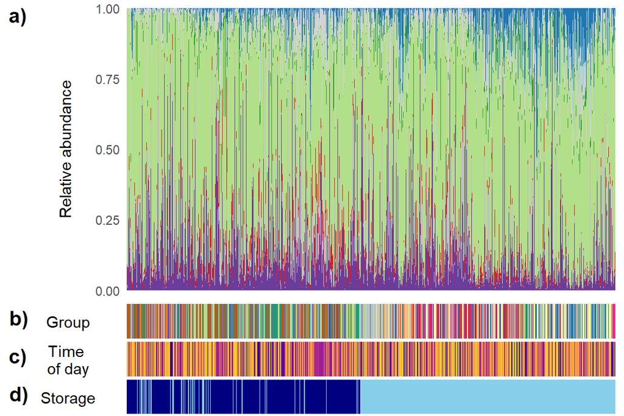

```r
mypalx[9]<-"grey"



plot_group<-ggplot(class_per_sample, aes(y = 1, x = reorder(Sample, SampleDate), fill = GroupAtSampling_plot))+
  geom_tile()+
  theme_void()+
   scale_fill_manual(values = mypalx)+
   theme(axis.title.y = element_text(angle = 0))+
  ylab("Group")+
  labs(fill = "Group")+
  guides(fill=guide_legend(ncol=2))


# storage

plot_storage<-ggplot(class_per_sample, aes(y = 1, x = reorder(Sample, SampleDate), fill = Storage))+
  geom_tile()+
 theme_void()+
 # theme_bw()+
  scale_fill_manual(values = c("skyblue", "navyblue"), guide = guide_legend(reverse = TRUE))+
  theme(legend.position="right", legend.direction="vertical",
         legend.key.height = unit(0.2, 'cm'),
        legend.justification = c("left", "top"), legend.title=element_blank())+
   theme(plot.margin=unit(c(0,0.2,0,0.2),"cm"))+
   theme(axis.title.y = element_text(angle = 0))+
  ylab("Storage")

# time

plot_time<-ggplot(class_per_sample, aes(y = 1, x = reorder(Sample, SampleDate), fill = HoursAfterSunrise))+geom_tile()+
  theme_void()+
 scale_fill_viridis_c(option = "plasma", direction= -1)+
   theme(legend.position="right", legend.direction="horizontal",
        legend.justification = c("left", "top"),
        legend.key.height = unit(0.2, 'cm'),
        legend.title=element_blank())+
   theme(axis.title.y = element_text(angle = 0))+
  ylab("Time \nof day")

ggarrange(plot_per_sample,  plot_group,plot_time, plot_storage, ncol = 1, align = "v", heights = c(8,1,1, 1), labels= c("a)", "b)", "c)", "d)"), legend = F)
```

This chunk took 0.36 minutes

# 6 Fig S3. Visualising raw data per individual

```r
meerkat_merged_ID<-merge_samples(meerkat_filtered,"IndividID", fun=mean)
sample_data(meerkat_merged_ID)$IndividID<-sample_names(meerkat_merged_ID)
meerkat_merged_ID_class<-tax_glom(meerkat_merged_ID, taxrank = "Class")
sample_data(meerkat_merged_ID_class)<-sample_data(meerkat_merged_ID_class)[,"IndividID"]
meerkat_merged_ID_class<-microbiome::transform(meerkat_merged_ID_class, "compositional")
class_per_ID<-psmelt(meerkat_merged_ID_class)

class_abundance<-class_per_ID %>% group_by(Class) %>% summarise(mean = mean(Abundance))
class_abundance<-class_abundance[order(-class_abundance$mean),]
top_class<-class_abundance$Class[1:7]

class_per_ID$Class_plot<-as.character(ifelse(class_per_ID$Class %in% top_class, class_per_ID$Class, "Other"))


class_per_ID$Class_plot<-factor(class_per_ID$Class_plot, levels = c("Bacteroidia","Fusobacteriia" ,  "Other","Gammaproteobacteria", "Clostridia",
"Coriobacteriia","Actinobacteria",    "Bacilli"))

## order by birthyear #####
## order by birthyear #####
## order by birthyear #####
## order by birthyear #####

metadata<-data.frame(sample_data(meerkat_filtered))
metadata$BirthYear<-lubridate::year(sample_data(meerkat_filtered)$BirthDate)
metadata<-metadata[,c("feature.id", "IndividID", "TB_status", "BirthYear","BirthDate")]
head(metadata)
```

|  | feature.id | IndividID | TB_status | BirthYear | BirthDate |
| --- | --- | --- | --- | --- | --- |
| Feature1 | Feature1 | ID 69 | Unexposed | 1997 | 1997-03-03 |
| Feature3 | Feature3 | ID 69 | Unexposed | 1997 | 1997-03-03 |
| Feature5 | Feature5 | ID 4 | Unexposed | 1998 | 1998-10-21 |
| Feature7 | Feature7 | ID 92 | Unexposed | 2000 | 2000-03-16 |
| Feature8 | Feature8 | ID 1 | Unexposed | 1996 | 1996-01-03 |
| Feature10 | Feature10 | ID 35 | Diseased | 1999 | 1999-01-20 |

```r
metadata2<-distinct(metadata, IndividID, .keep_all = T)
metadata2<-metadata2 %>% arrange(BirthDate)
head(metadata2)
```

|  | feature.id | IndividID | TB_status | BirthYear | BirthDate |
| --- | --- | --- | --- | --- | --- |
| Feature8 | Feature8 | ID 1 | Unexposed | 1996 | 1996-01-03 |
| Feature751 | Feature751 | ID 50 | Unexposed | 1996 | 1996-03-11 |
| Feature915 | Feature915 | ID 2 | Unexposed | 1996 | 1996-03-21 |
| Feature1 | Feature1 | ID 69 | Unexposed | 1997 | 1997-03-03 |
| Feature161 | Feature161 | ID 3 | Diseased | 1997 | 1997-11-02 |
| Feature49 | Feature49 | ID 79 | Unexposed | 1998 | 1998-02-04 |

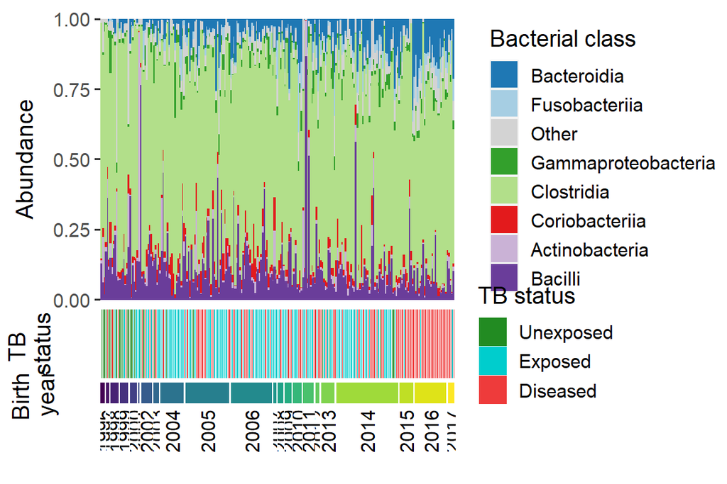

```r
ID_order<-metadata2$IndividID


class_per_ID<-merge(class_per_ID, metadata2, by.y = "IndividID", by.x = "Sample")

class_per_ID$TB_status<-factor(class_per_ID$TB_status, levels = c("unexposed", "exposed_asymptomatic", "exposed_symptomatic"))

levels(class_per_ID$TB_status)<-c("TB unexposed", "TB exposed", "TB diseased")

metadata2$IndividID<-factor(metadata2$IndividID, levels =ID_order)
class_per_ID$IndividID<-factor(class_per_ID$IndividID, levels =ID_order)


#class_per_ID<-class_per_ID%>% group_by(IndividID, Class_plot)%>%summarize(Abundance = sum(Abundance))
class_per_ID<-data.frame(class_per_ID)

#########################
#########################
#########################
#########################

microbiome_barplot <- ggplot(class_per_ID, aes(x = IndividID, y = Abundance, fill = Class_plot, col = Class_plot))+
  theme_gray(base_size = 14)+
  geom_bar( stat="identity", width = 0.5)+
  scale_fill_manual(values = rev(pal))+
  scale_color_manual(values = rev(pal), guide = "none")+
  theme(legend.position = "right")+
  theme(axis.text.x = element_blank(), axis.title.x = element_blank(), axis.ticks.x = element_blank())+
   theme(plot.margin=unit(c(0.4,0,0,0),"cm"))+
     scale_y_continuous(expand = c(0,0)) +
  labs(fill = "Bacterial class")+
  theme(legend.justification = c("left", "center"))


######## TB

p2<-ggplot(metadata2, aes(x = IndividID, y = 1, fill = TB_status))+
  geom_tile(col = "white")+
  theme_void(base_size = 14)+
  scale_fill_manual(values = c("forestgreen", "cyan3", "brown2"))+
  theme(legend.position = "right", legend.justification = "left") +
  theme(axis.text.x = element_blank(), axis.title.x = element_blank(), axis.ticks.x = element_blank())+
  theme(axis.text.y = element_blank())+
      theme(axis.title.y = element_text(angle = 90, vjust=0.5))+
  ylab("TB \nstatus")+
   theme(plot.margin=unit(c(0,0,0,0.1),"cm"))+
  labs(fill = "TB status")



######## birth year




p3<-ggplot(metadata2, aes(y = 1, x = IndividID, fill = BirthYear))+
  geom_tile()+
  theme_void(base_size = 14)+
  scale_fill_viridis(discrete = F)+
  facet_grid(~BirthYear, scales = "free", space = "free_x",switch = "x")+

  theme(panel.spacing = unit(0.05, "lines"),
         strip.background = element_blank(),
         strip.placement = "outside",
         strip.text.x = element_text(angle = 90, size = , hjust = 0.5)) +

   xlab("")+
    theme(axis.title.y = element_text(angle = 90, vjust=9))+
  ylab("Birth \nyear")+
  theme(axis.title.x = element_text(colour = "black"))+
   theme(plot.margin=unit(c(0, 5.7, 0.2,1.1),"cm"))+
  theme(legend.position="none")



figsxab<-ggarrange(microbiome_barplot,p2, ncol = 1, align = "v", heights = c(2,0.5))

ggarrange(figsxab, p3, ncol = 1, heights = c(3,0.8))
```

```r
#ggsave("Figures/FigS6.pdf")
# Saving 16.9 x 7.97 in image
```

This chunk took 0.27 minutes

- changes in relative abundances of Bacteroidia and Bacilli

```r
bacteroidia_2005<-subset(class_per_ID, Class_plot == "Bacteroidia" & BirthYear <2006 )
bacteroidia_2014<-subset(class_per_ID, Class_plot == "Bacteroidia"& BirthYear >2013 )

length(unique(bacteroidia_2005$IndividID))
```

```
## [1] 84
```

```r
length(unique(bacteroidia_2014$IndividID))
```

```
## [1] 83
```

```r
summary(bacteroidia_2005$Abundance)
```

```
##     Min.  1st Qu.   Median     Mean  3rd Qu.     Max.
## 0.000000 0.004754 0.017053 0.037109 0.048031 0.255336
```

```r
sd(bacteroidia_2005$Abundance)
```

```
## [1] 0.04815908
```

```r
summary(bacteroidia_2014$Abundance)
```

```
##     Min.  1st Qu.   Median     Mean  3rd Qu.     Max.
## 0.000689 0.048280 0.099646 0.100043 0.141796 0.327672
```

```r
sd(bacteroidia_2014$Abundance)
```

```
## [1] 0.06791717
```

```r
bacilli_2005<-subset(class_per_ID, Class_plot == "Bacilli" & BirthYear <2006 )
bacilli_2014<-subset(class_per_ID, Class_plot == "Bacilli"& BirthYear >2014 )

summary(bacilli_2005$Abundance)
```

```
##     Min.  1st Qu.   Median     Mean  3rd Qu.     Max.
## 0.006604 0.062771 0.095245 0.131469 0.163677 0.765236
```

```r
sd(bacilli_2005$Abundance)
```

```
## [1] 0.1176245
```

```r
summary(bacilli_2014$Abundance)
```

```
##     Min.  1st Qu.   Median     Mean  3rd Qu.     Max.
## 0.009551 0.033834 0.052679 0.074724 0.103429 0.326442
```

```r
sd(bacilli_2014$Abundance)
```

```
## [1] 0.06493677
```

This chunk took 0 minutes

# 7 Figs S4, S5 and S9. Split by storage, season and group

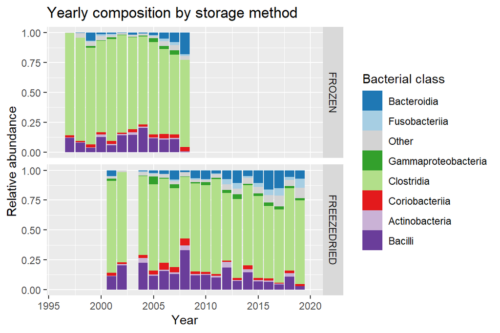

```r
storage_ps_class<-tax_glom(meerkat_filtered, taxrank = "Class")

storage_ps_class<-core(storage_ps_class, detection = 10, prevalence = 0)

sample_data(storage_ps_class)<-sample_data(storage_ps_class)[,c("feature.id", "Storage", "IndividID", "Year", "TimeCat")]
class_per_storage<-psmelt(storage_ps_class)

class_per_storage$Class_plot<-as.character(ifelse(class_per_storage$Class %in% top_class, class_per_storage$Class, "Other"))



class_per_storage$Class_plot<-factor(class_per_storage$Class_plot, levels = c("Bacteroidia","Fusobacteriia" ,  "Other","Gammaproteobacteria", "Clostridia",
"Coriobacteriia","Actinobacteria",    "Bacilli"))


class_per_storage$Storage<-factor(class_per_storage$Storage, levels = c("FROZEN", "FREEZEDRIED"))


################

class_per_storage$Storage<-factor(class_per_storage$Storage, levels = c("FROZEN", "FREEZEDRIED"))

ggplot(class_per_storage, aes(x =Year, y = Abundance, fill = Class_plot))+
  geom_col(position = "fill", stat="identity", size = 0)+
  ylab("Relative abundance")+
 facet_wrap(~Storage, ncol = 1, strip.position="right")+
  scale_fill_manual(values = rev(pal))+
  xlim(c(1996, 2020))+
 # theme(plot.margin=unit(c(0.2,0,0,0.1),"cm"))+
  labs(fill = "Bacterial class")+
  ggtitle("Yearly composition by storage method")
```

This chunk took 0.16 minutes

- Time of day

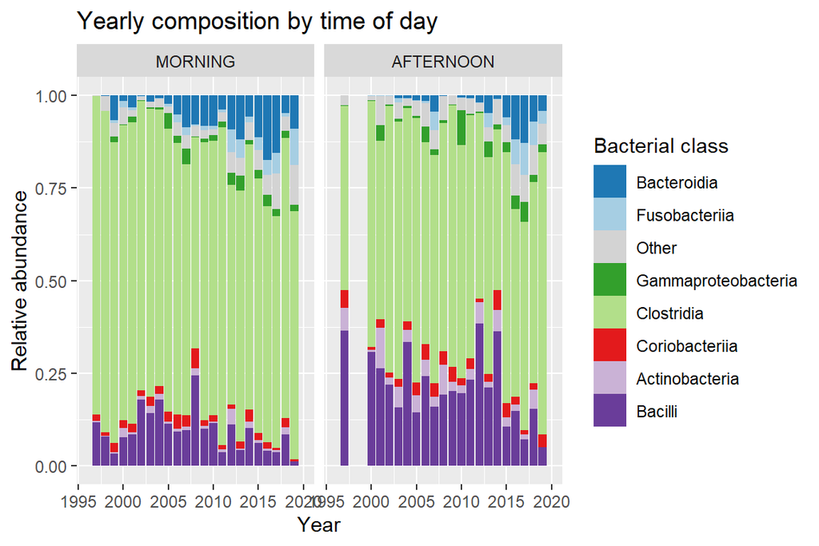

```r
# time time of day

class_per_storage$TimeCat <- factor(class_per_storage$TimeCat, levels = c( "MORNING", "AFTERNOON"))

ggplot(class_per_storage, aes(x =Year, y = Abundance, fill = Class_plot))+
  geom_col(position = "fill", stat="identity", size = 0)+
  ylab("Relative abundance")+
 facet_wrap(~TimeCat, ncol = 2)+
  scale_fill_manual(values = rev(pal))+
  xlim(c(1996, 2020))+
 # theme(plot.margin=unit(c(0.2,0,0,0.1),"cm"))+
  labs(fill = "Bacterial class")+
  ggtitle("Yearly composition by time of day")
```

This chunk took 0.1 minutes

- Season

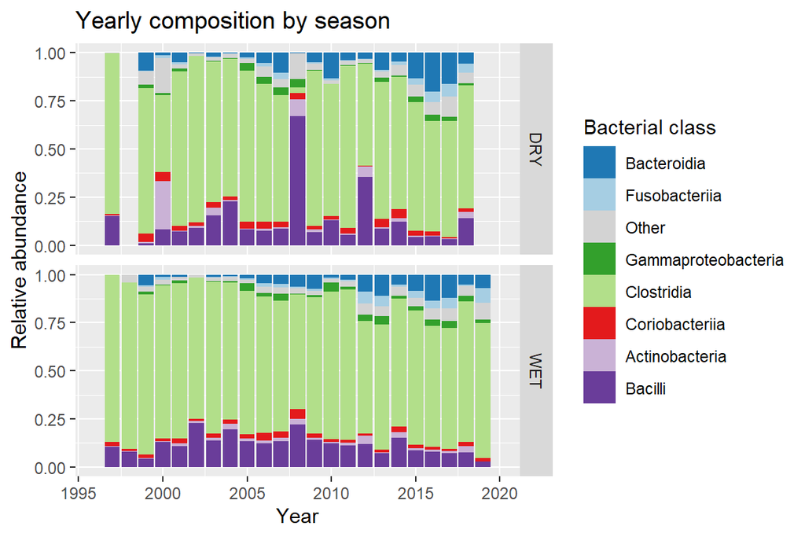

```r
## season

season_ps_class<-tax_glom(meerkat_filtered, taxrank = "Class")

season_ps_class<-core(season_ps_class, detection = 10, prevalence = 0)

sample_data(season_ps_class)<-sample_data(season_ps_class)[,c("feature.id", "Season", "IndividID", "Year")]
class_per_season<-psmelt(season_ps_class)

class_per_season$Class_plot<-as.character(ifelse(class_per_season$Class %in% top_class, class_per_season$Class, "Other"))



class_per_season$Class_plot<-factor(class_per_season$Class_plot, levels = c("Bacteroidia","Fusobacteriia" ,  "Other","Gammaproteobacteria", "Clostridia",
"Coriobacteriia","Actinobacteria",    "Bacilli"))


################


ggplot(class_per_season, aes(x =Year, y = Abundance, fill = Class_plot))+
  geom_col(position = "fill", stat="identity", size = 0)+
  ylab("Relative abundance")+
 facet_wrap(~Season, ncol = 1, strip.position="right")+
  scale_fill_manual(values = rev(pal))+
  xlim(c(1996, 2020))+
 # theme(plot.margin=unit(c(0.2,0,0,0.1),"cm"))+
  labs(fill = "Bacterial class")+
  ggtitle("Yearly composition by season")
```

This chunk took 0.14 minutes

- Social groups

```r
metadata_groups<-data.frame(sample_data(meerkat_filtered))

group_freq<-data.frame(table(metadata_groups$GroupAtSampling))

group_freq<-group_freq %>% arrange(-Freq)
head(group_freq, 10)
```

|  | Var1 | Freq |
| --- | --- | --- |
| 1 | Van Helsing | 159 |
| 2 | Vivian | 136 |
| 3 | Baobab | 124 |
| 4 | Commandos | 102 |
| 5 | Whiskers | 93 |
| 6 | Zulus | 64 |
| 7 | Ewoks | 62 |
| 8 | Zappa | 61 |
| 9 | Rascals | 55 |
| 10 | Lazuli | 43 |

```r
top_groups<-group_freq$Var1[1:15]


group_ps_class<-tax_glom(meerkat_filtered, taxrank = "Class")

group_ps_class<-core(group_ps_class, detection = 10, prevalence = 0)

sample_data(group_ps_class)<-sample_data(group_ps_class)[,c("feature.id", "Storage", "IndividID", "Year", "SampleDate", "GroupAtSampling")]
class_per_storage<-psmelt(group_ps_class)

class_per_storage$Class_plot<-as.character(ifelse(class_per_storage$Class %in% top_class, class_per_storage$Class, "Other"))



class_per_storage$Class_plot<-factor(class_per_storage$Class_plot, levels = c("Bacteroidia","Fusobacteriia" ,  "Other","Gammaproteobacteria", "Clostridia",
"Coriobacteriia","Actinobacteria",    "Bacilli"))

class_per_storage$Group_plot<-ifelse(class_per_storage$GroupAtSampling %in% top_groups, as.character(class_per_storage$GroupAtSampling), "Other")



class_per_storage$Group_plot<-forcats::fct_reorder(class_per_storage$Group_plot, class_per_storage$Year, mean)

length(unique(subset(class_per_storage, Group_plot != "Other")$feature.id))
```

```
## [1] 1003
```

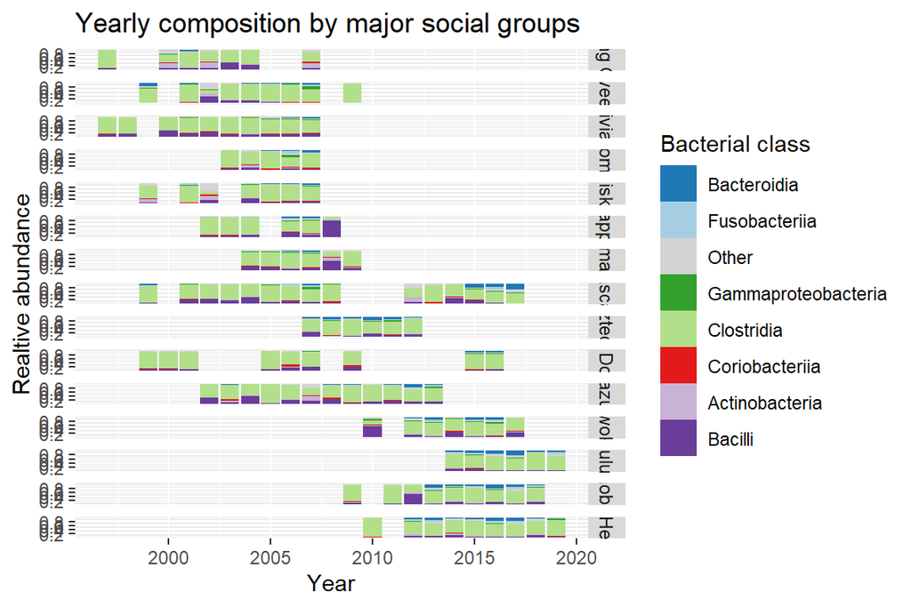

```r
ggplot(subset(class_per_storage, Group_plot != "Other"), aes(x =Year, y = Abundance, fill = Class_plot))+
  geom_col(position = "fill", stat="identity", size = 0)+
  ylab("Realtive abundance")+
  scale_fill_manual(values = rev(pal))+
  facet_wrap(~Group_plot, ncol = 1, strip.position="right")+
  ggtitle("Yearly composition by major social groups")+
  scale_y_continuous(breaks = c(0.2, 0.4, 0.6, 0.8))+
  labs(fill = "Bacterial class")
```

This chunk took 0.16 minutes

# 8 Fig 3: Microbiome composition by year barplot

```r
meerkat_merged_year<-merge_samples(meerkat_filtered,"Year", fun=mean)

sample_data(meerkat_merged_year)$Year<-sample_names(meerkat_merged_year)

meerkat_merged_year_class<-tax_glom(meerkat_merged_year, taxrank = "Class")

sample_data(meerkat_merged_year_class)<-sample_data(meerkat_merged_year_class)[,1]

#meerkat_merged_year_class<-microbiome::transform(meerkat_merged_year_class, "compositional")
class_per_year<-psmelt(meerkat_merged_year_class)



class_per_year$Class_plot<-as.character(ifelse(class_per_year$Class %in% top_class, class_per_year$Class, "Other"))

class_per_year$Class_plot<-factor(class_per_year$Class_plot, levels = c("Bacteroidia","Fusobacteriia" ,  "Other","Gammaproteobacteria", "Clostridia",
"Coriobacteriia","Actinobacteria",    "Bacilli"))

class_per_year$Sample<- as.integer(class_per_year$Sample)

class_per_year<-class_per_year%>% group_by(Sample, Class_plot)%>%summarize(Abundance = sum(Abundance))
class_per_year<-data.frame(class_per_year)
class_per_year$Sample<-factor(class_per_year$Sample)


plot_mb_year<-ggplot(class_per_year, aes(x =Sample, y = Abundance, fill = Class_plot))+
  geom_bar( stat="identity",  size = 0, position = "fill")+
   theme_bw()+
  scale_fill_manual(values = rev(pal))+
  theme(legend.position = "right")+
  xlab("")+
  theme(axis.text.x = element_text(angle = 90, vjust = 0.9, hjust=1))+
  labs(fill = "Bacterial class")+
   scale_y_continuous(expand = c(0,0))+
  xlab("Year")


year_freq<-data.frame(table(sample_data(meerkat_filtered)$Year))


year_hist<-ggplot(year_freq, aes(x = Var1, y = Freq)) + geom_col(fill = "lightgray", col = "black")+
# theme(plot.margin=unit(c(0.2,5,0.2,0.2),"cm"))+
  theme(axis.text.x = element_blank(), axis.title.x = element_blank())+
  theme(legend.position = "none")+
  scale_y_sqrt(breaks = c(0,20,50,100,200))+
  geom_hline(yintercept = 20, col = "black", linetype = "longdash")

year_plot<-ggarrange(year_hist, plot_mb_year, ncol = 1, align = "v", heights = c(1,7), legend = "none")+
     theme(plot.margin=unit(c(0.2,0.2,0.2,0.6),"cm"))

## tb

TB_summary_year2<-subset(TB_summary_year, TB_status == "TB diseased")



extra_rows<-data.frame(as.integer(1997), as.factor("TB diseased")   , as.integer(0) ,  as.integer(165) ,as.numeric(0) ,as.numeric(0))
names(extra_rows)<-names(TB_summary_year2)

extra_rows2<-data.frame(as.integer(1998), as.factor("TB diseased")   , as.integer(0) ,  as.integer(165) ,as.numeric(0) ,as.numeric(0))
names(extra_rows2)<-names(TB_summary_year2)


TB_summary_year3<-rbind(TB_summary_year2, extra_rows, extra_rows2)
TB_summary_year3$Year<-factor(TB_summary_year3$Year)
summary(TB_summary_year3)
```

```
##       Year           TB_status       freq           Total
##  1997   : 1   TB unexposed: 0   Min.   : 0.00   Min.   :165.0
##  1998   : 1   TB exposed  : 0   1st Qu.: 7.50   1st Qu.:284.5
##  1999   : 1   TB diseased :23   Median :37.00   Median :356.0
##  2000   : 1                     Mean   :35.48   Mean   :341.3
##  2001   : 1                     3rd Qu.:59.00   3rd Qu.:416.5
##  2002   : 1                     Max.   :81.00   Max.   :452.0
##  (Other):17
##    Proportion            se
##  Min.   :0.00000   Min.   :0.000000
##  1st Qu.:0.02382   1st Qu.:0.008278
##  Median :0.09160   Median :0.014551
##  Mean   :0.10353   Mean   :0.013787
##  3rd Qu.:0.15807   3rd Qu.:0.018940
##  Max.   :0.29412   Max.   :0.029535
##
```

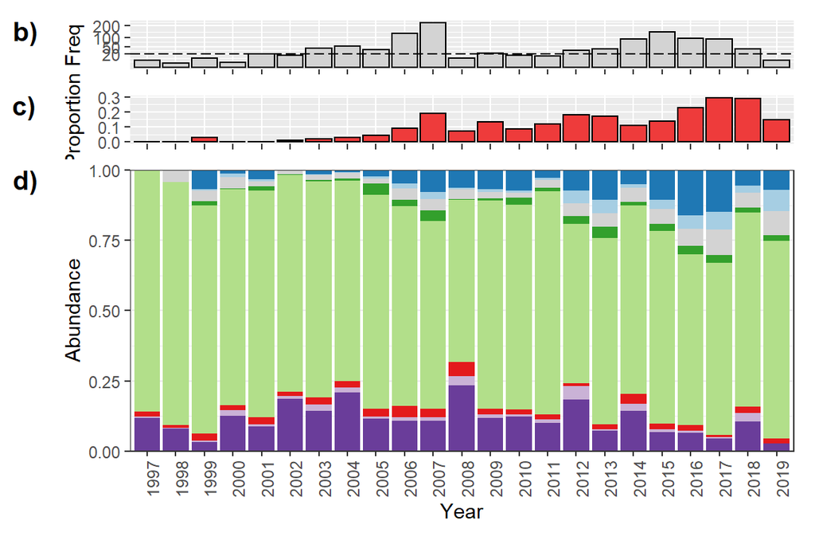

```r
TB_hist<-ggplot(TB_summary_year3, aes(y = Proportion, x = Year))+
  geom_col(fill = "brown2", col = "black")+
# theme(plot.margin=unit(c(0.2,5,0.2,0.2),"cm"))+
  theme(axis.text.x = element_blank(), axis.title.x = element_blank())+
  theme(legend.position = "none")

year_plot<-ggarrange(year_hist, TB_hist, plot_mb_year, ncol = 1, align = "v", heights = c(1,1, 5), legend = "none", labels = c("b)", "c)", "d)"), label.x = -0.07)+
     theme(plot.margin=unit(c(0.2,0.2,0.2,1),"cm"))

year_plot
```

This chunk took 0.1 minutes

# 9 Constrained ordination

- Constrained ordination using CAP
- Also test all supertypes

```r
scaled_core<-microbiome::core(meerkat_filtered, detection = 100, prevalence = 0.01)

scaled_core<-tax_glom(meerkat_filtered, taxrank = "Genus")

scaled_core<-microbiome::core(scaled_core, detection = 10, prevalence = 0.005)

scaled_core
```

```
## phyloseq-class experiment-level object
## otu_table()   OTU Table:          [ 499 taxa and 1141 samples ]:
## sample_data() Sample Data:        [ 1141 samples by 32 sample variables ]:
## tax_table()   Taxonomy Table:     [ 499 taxa by 7 taxonomic ranks ]:
## phy_tree()    Phylogenetic Tree:  [ 499 tips and 498 internal nodes ]:
## taxa are rows
```

This chunk took 0.14 minutes

- organise variables

```r
# otutable

otutable<-data.frame(t(scaled_core@otu_table@.Data))
dim(otutable)
```

```
## [1] 1141  499
```

```r
otutable[1:5,1:5]
```

|  | a29558bc215cfe6f913afafef02450b9 | de14e4fbd65f5ea24336f74fca93998d | b1a40d7ca4ef789afb38c8de415893eb | bd28d84ee5305bf27575469eb63ba948 | eb5e72c0f85766e6bd0130723b04144c |
| --- | --- | --- | --- | --- | --- |
| Feature1 | 0 | 0 | 0 | 0 | 0 |
| Feature3 | 0 | 0 | 0 | 0 | 0 |
| Feature5 | 0 | 0 | 0 | 0 | 0 |
| Feature7 | 0 | 0 | 0 | 0 | 1 |
| Feature8 | 0 | 0 | 0 | 0 | 0 |

```r
colnames(otutable)<-taxa_names(scaled_core)

metadata<-data.frame(sample_data(scaled_core))
names(metadata)
```

```
##  [1] "feature.id"          "IndividID"           "SampleDate"
##  [4] "SampleTime"          "Storage"             "Seq_run"
##  [7] "Imtechella"          "Allobacillus"        "Seq_depth"
## [10] "scaling_factor"      "Seq_depth_nospikein" "BirthDate"
## [13] "DeathDate"           "AgeAtSampling"       "GroupAtSampling"
## [16] "Condition_weight"    "SocialStatus"        "Temp_max"
## [19] "sum_rainfall_month"  "HoursAfterSunrise"   "TimeCat"
## [22] "Year"                "month"               "Season"
## [25] "TB_status"           "TB_exposure"         "TB_resistance"
## [28] "TB_survival"         "TB_symptom_date"     "TB_exposure_date"
## [31] "TB_stage"            "TotalAbundance"
```

```r
## TB variables

TB_stage<-metadata$TB_stage
TB_status<-metadata$TB_status
TB_survival<-metadata$TB_survival


# condition and season

summary(metadata$Condition_weight)
```

```
##    Min. 1st Qu.  Median    Mean 3rd Qu.    Max.
## -274.47  -57.95  -15.40  -14.00   28.04  245.68
```

```r
metadata$Condition_cat <- ifelse(metadata$Condition_weight < summary(metadata$Condition_weight)[2], "BAD", "AVERAGE")
metadata$Condition_cat <- ifelse(metadata$Condition_weight > summary(metadata$Condition_weight)[5], "GOOD", metadata$Condition_cat)

condition<-metadata$Condition_cat
season <- metadata$Season

## rainfall

summary(log10(metadata$sum_rainfall_month+1))
```

```
##    Min. 1st Qu.  Median    Mean 3rd Qu.    Max.
##  0.0000  0.0000  0.8062  0.7770  1.3385  2.2896
```

```r
metadata$Rainfall_cat <- ifelse(metadata$sum_rainfall_month == summary(metadata$sum_rainfall_month)[2], "LOW", "AVERAGE")
metadata$Rainfall_cat <- ifelse(metadata$sum_rainfall_month > summary(metadata$sum_rainfall_month)[5], "HIGH", metadata$Rainfall_cat)
table(metadata$Rainfall_cat)
```

```
##
## AVERAGE    HIGH     LOW
##     541     281     319
```

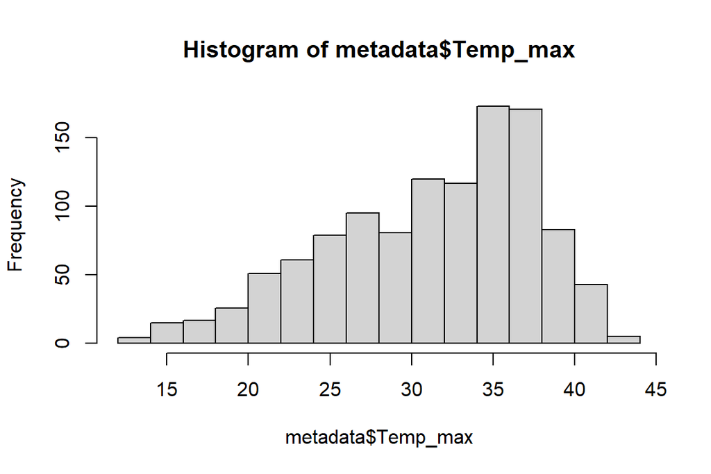

```r
# temp
hist(metadata$Temp_max)
```

```r
summary(metadata$Temp_max)
```

```
##    Min. 1st Qu.  Median    Mean 3rd Qu.    Max.
##   12.60   26.80   32.30   31.25   36.10   43.00
```

```r
metadata$Max_temp_cat <- ifelse(metadata$Temp_max < summary(metadata$Temp_max)[2], "LOW", "AVERAGE")
metadata$Max_temp_cat <- ifelse(metadata$Temp_max > summary(metadata$Temp_max)[5], "HIGH", metadata$Max_temp_cat)
table(metadata$Max_temp_cat)
```

```
##
## AVERAGE    HIGH     LOW
##     577     283     281
```

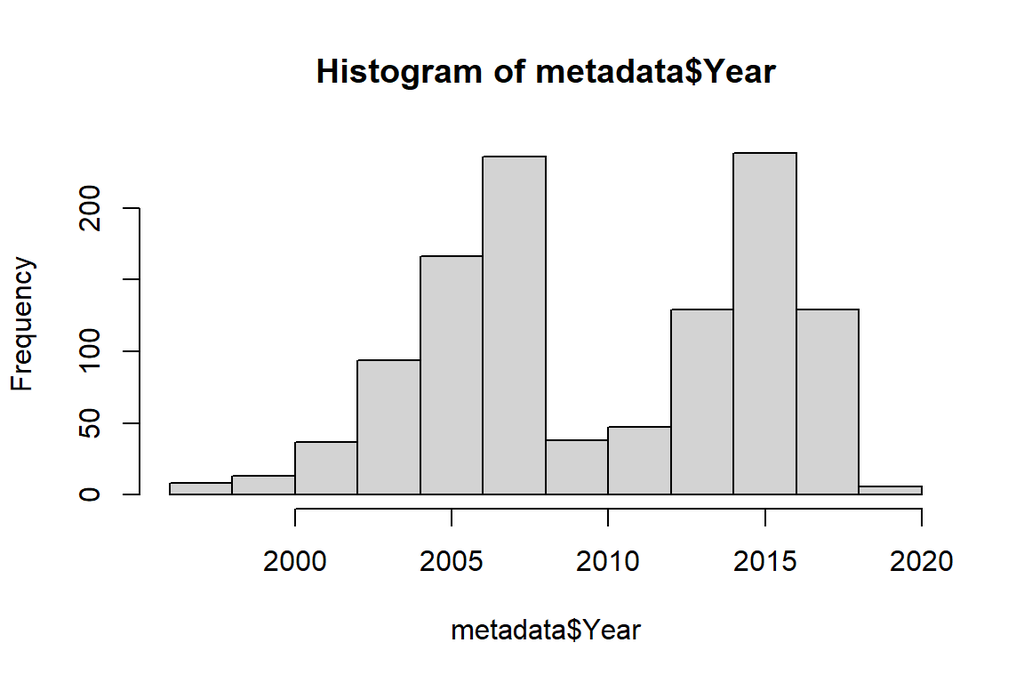

```r
## max temp

max_temp<-metadata$Max_temp_cat
#hist(max_temp)

# year

hist(metadata$Year)
```

```r
metadata<-metadata %>% mutate(YearCat = case_when((Year <2005 ~ "Pre-2005"),
                                                  (Year >=2005 & Year < 2010) ~ "2005-2010",
                                                  (Year >=2010 & Year < 2015) ~ "2010-2015",
                                                  (Year >=2015) ~ "2015-2019"))



YearCat<-as.character(metadata$YearCat)

### control variables
IndividID<-metadata$IndividID
time<-metadata$TimeCat
maxtemp<-metadata$Max_temp_cat
samplingtemp<-metadata$HourlyTemp
foraging<-log10(metadata$HoursSinceForagingStart+0.1)
rainfall<-metadata$Rainfall_cat
# methods
storage<-metadata$Storage
seq_depth<-as.numeric(scale(metadata$Seq_depth_nospikein))
seq_run<-metadata$Seq_run
```

This chunk took 0.01 minutes

- Generate distance matrices

```r
###### genus level

wunifrac_dist<-distance(scaled_core, method = "wunifrac")

unifrac_dist<-distance(scaled_core, method = "unifrac")

bray_dist<-distance(scaled_core, method = "bray")


# asv level ###

scaled_core_asv<-microbiome::core(meerkat_filtered, detection = 100, prevalence = 0.005)

wunifrac_dist_asv<-distance(scaled_core_asv, method = "wunifrac")

unifrac_dist_asv<-distance(scaled_core_asv, method = "unifrac")

bray_dist_asv<-distance(scaled_core_asv, method = "bray")
```

This chunk took 36.95 minutes

### 9.0.1 Apply constrained ordination models (dbRDA)

```r
# weighted unifrac

final_model<-capscale(wunifrac_dist ~
                       time +
                        TB_stage+
                        condition+
                        rainfall+
                       YearCat+
                        storage+
                        seq_depth+
                       IndividID,
                env = metadata, comm = otutable)

# weighted unifrac

final_model_anova<-anova.cca(final_model, by="terms")
final_model_anova
```

|  | Df | SumOfSqs | F | Pr(>F) |
| --- | --- | --- | --- | --- |
| time | 1 | 7.8397528 | 94.609831 | 0.001 |
| TB_stage | 2 | 1.5204280 | 9.174233 | 0.001 |
| condition | 2 | 0.4284690 | 2.585373 | 0.003 |
| rainfall | 2 | 0.4875947 | 2.942137 | 0.002 |
| YearCat | 3 | 2.6324176 | 10.589304 | 0.001 |
| storage | 1 | 0.1813851 | 2.188948 | 0.019 |
| seq_depth | 1 | 0.5935519 | 7.162961 | 0.001 |
| IndividID | 234 | 22.9836168 | 1.185322 | 0.001 |
| Residual | 894 | 74.0804518 | NA | NA |

```r
final_model_anova_df<-data.frame(final_model_anova)
RsquareAdj(final_model)
```

```
## $r.squared
## [1] 0.4318683
##
## $adj.r.squared
## [1] 0.2755368
```

```r
# write.csv(final_model_anova_df, "dbrda_wunifrac_summary_genus.csv")



## unweighted unifrac

unifrac_model<-capscale(unifrac_dist ~
                       time +
                        TB_stage+
                        condition+
                         rainfall+
                       YearCat+
                        storage+
                        seq_depth+
                       IndividID,
                env = metadata, comm = otutable)

## unweighted unifrac ##

unifrac_anova<-anova.cca(unifrac_model, by="terms")
unifrac_anova
```

|  | Df | SumOfSqs | F | Pr(>F) |
| --- | --- | --- | --- | --- |
| time | 1 | 12.474851 | 57.801977 | 0.001 |
| TB_stage | 2 | 3.639075 | 8.430790 | 0.001 |
| condition | 2 | 1.096169 | 2.539539 | 0.001 |
| rainfall | 2 | 1.542201 | 3.572880 | 0.001 |
| YearCat | 3 | 6.181763 | 9.547692 | 0.001 |
| storage | 1 | 0.314803 | 1.458633 | 0.081 |
| seq_depth | 1 | 1.824537 | 8.453956 | 0.001 |
| IndividID | 234 | 55.137089 | 1.091780 | 0.001 |
| Residual | 894 | 192.943522 | NA | NA |

```r
unifrac_anova_df<-data.frame(unifrac_anova)
#write.csv(unifrac_anova_df, "dbrda_unifrac_summary_genus.csv")


bray_model<-capscale(bray_dist ~
                       time +
                        TB_stage+
                        condition+
                          rainfall+
                       YearCat+
                        storage+
                        seq_depth+
                       IndividID,
                env = metadata, comm = otutable)

bray_anova<-anova.cca(bray_model, by="terms")
bray_anova
```

|  | Df | SumOfSqs | F | Pr(>F) |
| --- | --- | --- | --- | --- |
| time | 1 | 29.8099868 | 90.335408 | 0.001 |
| TB_stage | 2 | 4.3857294 | 6.645200 | 0.001 |
| condition | 2 | 1.2367585 | 1.873920 | 0.009 |
| rainfall | 2 | 1.9449864 | 2.947018 | 0.001 |
| YearCat | 3 | 8.2298207 | 8.313145 | 0.001 |
| storage | 1 | 0.5694827 | 1.725746 | 0.038 |
| seq_depth | 1 | 2.2446824 | 6.802227 | 0.001 |
| IndividID | 234 | 91.3390831 | 1.182870 | 0.001 |
| Residual | 894 | 295.0130943 | NA | NA |

```r
bray_anova_df<-data.frame(bray_anova)
#write.csv(bray_anova_df, "dbrda_bray_summary_genus.csv")


#### ASV level ########
#### ASV level ########
#### ASV level ########
#### ASV level ########
#### ASV level ########


# weighted unifrac

wunifrac_model_asv<-capscale(wunifrac_dist_asv ~
                       time +
                        TB_stage+
                        condition+
                        rainfall+
                       YearCat+
                        storage+
                        seq_depth+
                       IndividID,
                env = metadata, comm = otutable)

# weighted unifrac

wunifrac_asv_anova<-anova.cca(wunifrac_model_asv, by="terms")
wunifrac_asv_anova
```

|  | Df | SumOfSqs | F | Pr(>F) |
| --- | --- | --- | --- | --- |
| time | 1 | 6.4632020 | 79.172274 | 0.001 |
| TB_stage | 2 | 1.4874873 | 9.110635 | 0.001 |
| condition | 2 | 0.4528152 | 2.773425 | 0.001 |
| rainfall | 2 | 0.4826365 | 2.956076 | 0.001 |
| YearCat | 3 | 2.7377133 | 11.178721 | 0.001 |
| storage | 1 | 0.1551730 | 1.900822 | 0.034 |
| seq_depth | 1 | 0.5405826 | 6.621974 | 0.001 |
| IndividID | 234 | 22.2659897 | 1.165605 | 0.001 |
| Residual | 894 | 72.9813890 | NA | NA |

```r
## unweighted unifrac

unifrac_model_asv<-capscale(unifrac_dist_asv ~
                       time +
                        TB_stage+
                        condition+
                         rainfall+
                       YearCat+
                        storage+
                        seq_depth+
                       IndividID,
                env = metadata, comm = otutable)

## unweighted unifrac ##

unifrac_asv_anova<-anova.cca(unifrac_model_asv, by="terms")
unifrac_asv_anova
```

|  | Df | SumOfSqs | F | Pr(>F) |
| --- | --- | --- | --- | --- |
| time | 1 | 10.5301955 | 49.933467 | 0.001 |
| TB_stage | 2 | 4.4285676 | 10.499982 | 0.001 |
| condition | 2 | 1.2353615 | 2.929000 | 0.001 |
| rainfall | 2 | 1.7630631 | 4.180162 | 0.001 |
| YearCat | 3 | 8.4310851 | 13.326543 | 0.001 |
| storage | 1 | 0.3257345 | 1.544611 | 0.051 |
| seq_depth | 1 | 2.9571551 | 14.022627 | 0.001 |
| IndividID | 234 | 56.9724910 | 1.154528 | 0.001 |
| Residual | 894 | 188.5307665 | NA | NA |

```r
bray_model_asv<-capscale(bray_dist_asv ~
                       time +
                        TB_stage+
                        condition+
                          rainfall+
                       YearCat+
                        storage+
                        seq_depth+
                       IndividID,
                env = metadata, comm = otutable)

bray_asv_anova<-anova.cca(bray_model_asv, by="terms")
bray_asv_anova
```

|  | Df | SumOfSqs | F | Pr(>F) |
| --- | --- | --- | --- | --- |
| time | 1 | 23.0149846 | 60.176339 | 0.001 |
| TB_stage | 2 | 4.6817862 | 6.120637 | 0.001 |
| condition | 2 | 1.7042578 | 2.228027 | 0.001 |
| rainfall | 2 | 1.9120555 | 2.499687 | 0.001 |
| YearCat | 3 | 9.4349762 | 8.223082 | 0.001 |
| storage | 1 | 0.6362118 | 1.663477 | 0.016 |
| seq_depth | 1 | 2.0682388 | 5.407739 | 0.001 |
| IndividID | 234 | 104.5612659 | 1.168342 | 0.001 |
| Residual | 894 | 341.9183776 | NA | NA |

This chunk took 44.63 minutes

- Get dominant classes per sample

```r
##dominant taxa

dominant_phylo<-scaled_core
#dominant_phylo<-scaled_core_genus
sample_data(dominant_phylo)<-sample_data(dominant_phylo)[,"feature.id"]

# melt data
psmelt_df<-speedyseq::psmelt(dominant_phylo)
head(psmelt_df)
```

|  | OTU | Sample | Abundance | feature.id | Kingdom | Phylum | Class | Order | Family | Genus | Species |
| --- | --- | --- | --- | --- | --- | --- | --- | --- | --- | --- | --- |
| 1 | 4ebcf74b2783b601ceaf1ca7a994420a | Feature1064 | 626918 | Feature1064 | Bacteria | Firmicutes | Clostridia | Clostridiales | Clostridiaceae 1 | Clostridium sensu stricto 1 | NA |
| 2 | 4ebcf74b2783b601ceaf1ca7a994420a | Feature315 | 493546 | Feature315 | Bacteria | Firmicutes | Clostridia | Clostridiales | Clostridiaceae 1 | Clostridium sensu stricto 1 | NA |
| 3 | 4ebcf74b2783b601ceaf1ca7a994420a | Feature1015 | 411615 | Feature1015 | Bacteria | Firmicutes | Clostridia | Clostridiales | Clostridiaceae 1 | Clostridium sensu stricto 1 | NA |
| 4 | 4ebcf74b2783b601ceaf1ca7a994420a | Feature1040 | 379282 | Feature1040 | Bacteria | Firmicutes | Clostridia | Clostridiales | Clostridiaceae 1 | Clostridium sensu stricto 1 | NA |
| 5 | d8e7f9181e4d5a4a6453e9ca9996a43f | Feature953 | 376774 | Feature953 | Bacteria | Bacteroidetes | Bacteroidia | Bacteroidales | Tannerellaceae | Parabacteroides | NA |
| 6 | 4ebcf74b2783b601ceaf1ca7a994420a | Feature1039 | 344486 | Feature1039 | Bacteria | Firmicutes | Clostridia | Clostridiales | Clostridiaceae 1 | Clostridium sensu stricto 1 | NA |

```r
dominant_taxa_df<-psmelt_df %>%
  group_by(feature.id) %>%
  arrange(feature.id, -Abundance) %>%
  dplyr::mutate(rank=rank(-Abundance))

head(dominant_taxa_df)
```

| OTU | Sample | Abundance | feature.id | Kingdom | Phylum | Class | Order | Family | Genus | Species | rank |
| --- | --- | --- | --- | --- | --- | --- | --- | --- | --- | --- | --- |
| 4ebcf74b2783b601ceaf1ca7a994420a | Feature1 | 80372 | Feature1 | Bacteria | Firmicutes | Clostridia | Clostridiales | Clostridiaceae 1 | Clostridium sensu stricto 1 | NA | 1 |
| 3dd7acf39ab927348aafcd8acb08dd9a | Feature1 | 27568 | Feature1 | Bacteria | Firmicutes | Clostridia | Clostridiales | Lachnospiraceae | Blautia | NA | 2 |
| 202bf1a869718cdabb7e842c74ec7e5c | Feature1 | 7769 | Feature1 | Bacteria | Actinobacteria | Coriobacteriia | Coriobacteriales | Coriobacteriaceae | Collinsella | NA | 3 |
| 807ab4dce101a0cca3e66c559d190b9a | Feature1 | 6410 | Feature1 | Bacteria | Firmicutes | Clostridia | Clostridiales | Peptostreptococcaceae | Peptoclostridium | NA | 4 |
| b712f6d712748de96eb148834a623ba1 | Feature1 | 1388 | Feature1 | Bacteria | Actinobacteria | Actinobacteria | Frankiales | Geodermatophilaceae | Geodermatophilus | NA | 5 |
| 1b85e321acab188aae7a2c36613f2371 | Feature1 | 1068 | Feature1 | Bacteria | Firmicutes | Clostridia | Clostridiales | Lachnospiraceae | [Ruminococcus] torques group | NA | 6 |

```r
dominant_taxa_df<-subset(dominant_taxa_df, rank ==1)
dominant_taxa_df$Class<-factor(dominant_taxa_df$Class)

# add to metadata
sample_data(scaled_core)$DomClass <-vlookup(sample_data(scaled_core)$feature.id, dominant_taxa_df, lookup_column = "Sample", result_column = "Class")

top_class
```

```
## [1] "Clostridia"          "Bacilli"             "Bacteroidia"
## [4] "Coriobacteriia"      "Actinobacteria"      "Fusobacteriia"
## [7] "Gammaproteobacteria"
```

```r
sample_data(scaled_core)$DomClass_plot<-ifelse(sample_data(scaled_core)$DomClass %in% top_class, as.character(sample_data(scaled_core)$DomClass), "Other")
unique(sample_data(scaled_core)$DomClass_plot)
```

```
## [1] "Clostridia"          "Other"               "Bacilli"
## [4] "Actinobacteria"      "Gammaproteobacteria" "Coriobacteriia"
## [7] "Fusobacteriia"       "Bacteroidia"
```

```r
#sample_data(scaled_core)$DomClass_plot<-factor(sample_data(scaled_core)$DomClass_plot, levels =c(top_class, "Other"))

sample_data(scaled_core)$DomClass_plot<-factor(sample_data(scaled_core)$DomClass_plot, levels = c("Bacteroidia","Fusobacteriia" ,  "Other","Gammaproteobacteria", "Clostridia",
"Coriobacteriia","Actinobacteria",    "Bacilli"))

pal<-brewer.pal(10,"Paired")
pal<-c(pal, "darkgrey")
pal<-pal[c(2,1,11,4,3,6,9,10)]
pal<-rev(pal)
```

This chunk took 0.03 minutes

### 9.0.2 Oridination figure

```r
######################################

## extract data from model

final_model_df<-scores(final_model)
str(final_model_df)
```

```
## List of 3
##  $ species  : num [1:499, 1:2] -2.34e-04 -1.57e-04 3.19e-06 1.82e-05 1.39e-04 ...
##   ..- attr(*, "dimnames")=List of 2
##   .. ..$ : chr [1:499] "a29558bc215cfe6f913afafef02450b9" "de14e4fbd65f5ea24336f74fca93998d" "b1a40d7ca4ef789afb38c8de415893eb" "bd28d84ee5305bf27575469eb63ba948" ...
##   .. ..$ : chr [1:2] "CAP1" "CAP2"
##  $ sites    : num [1:1141, 1:2] -0.658 -0.164 -0.795 1.257 0.517 ...
##   ..- attr(*, "dimnames")=List of 2
##   .. ..$ : chr [1:1141] "Feature1" "Feature3" "Feature5" "Feature7" ...
##   .. ..$ : chr [1:2] "CAP1" "CAP2"
##  $ centroids: num [1:252, 1:2] 0.5301 -0.271 -0.0647 0.0524 -0.0639 ...
##   ..- attr(*, "dimnames")=List of 2
##   .. ..$ : chr [1:252] "timeAFTERNOON" "timeMORNING" "TB_stageUnexposed" "TB_stageExposed" ...
##   .. ..$ : chr [1:2] "CAP1" "CAP2"
##  - attr(*, "const")= num 17.6
```

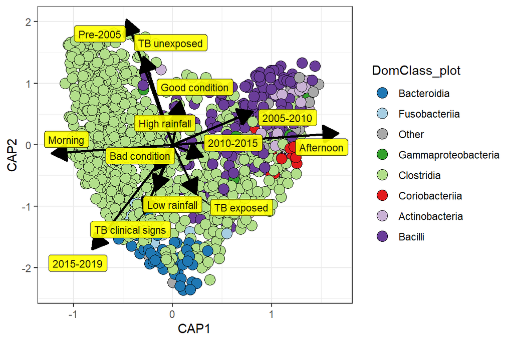

```r
# extract CAP scores

vectors_df<-data.frame(final_model_df$sites)

vectors_df$feature.id<-row.names(vectors_df)

# merge with info on dominant family

sample_metadata<-data.frame(sample_data(scaled_core))[,c("feature.id", "DomClass_plot")]
vectors_df<-merge(vectors_df, sample_metadata, by = "feature.id")



#### add arrows #########
#### add arrows #########
#### add arrows #########
#### add arrows #########

centroids_df<-data.frame(final_model_df$centroids)
centroids_df<-centroids_df[c(1:5,7:8,10:15),]
#centroids_df<-centroids_df[c(1,2,4,6:10,12:15),]
centroids_df$Label<-c("Afternoon", "Morning",  "TB unexposed", "TB exposed", "TB clinical signs", "Bad condition", "Good condition","High rainfall", "Low rainfall" , "2005-2010", "2010-2015", "2015-2019", "Pre-2005")

# scale so they are more plottable


centroids_df[1,1] <-centroids_df[1,1] *0.7
centroids_df[1,2] <-centroids_df[1,2] *0.7

centroids_df[13,1] <-centroids_df[13,1] *0.7
centroids_df[13,2] <-centroids_df[13,2] *0.7

centroids_df$CAP1<-centroids_df$CAP1 * 1.5
centroids_df$CAP2<-centroids_df$CAP2 * 1.5

ggplot(vectors_df, aes(x = CAP1, y = CAP2))+
  geom_point(aes(fill = DomClass_plot), pch = 21, size = 4)+
  scale_fill_manual(values = rev(pal))+
  theme_bw()+

  # add arrows

  geom_segment(data=centroids_df, aes(x = 0, y = 0, xend = CAP1*3, yend = CAP2*3),
    arrow = arrow(length = unit(0.5, "cm"), type = "closed"), lwd = 1,  col = "black")+
  ggrepel::geom_label_repel(data=centroids_df,
    alpha = 0.9, col = "black", size = 3, fill = "yellow",
    #hjust = c(0,1),
    #vjust = c(1,1),
    aes(CAP1 *3, CAP2*3, label = Label))
```

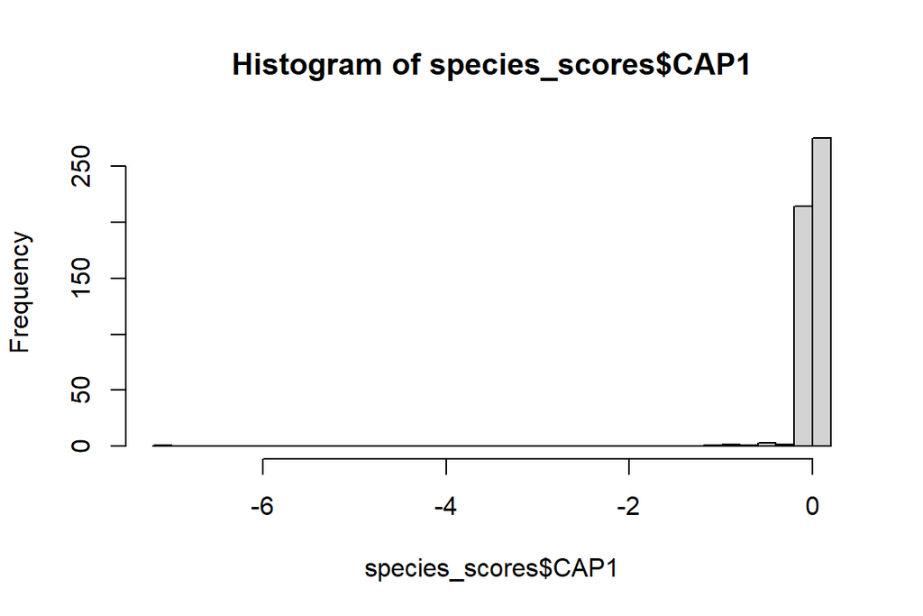

```r
### add species scores ###
### add species scores ###
### add species scores ###
### add species scores ###


species_scores<-data.frame(final_model_df$species)

hist(species_scores$CAP1, breaks = 50)
```

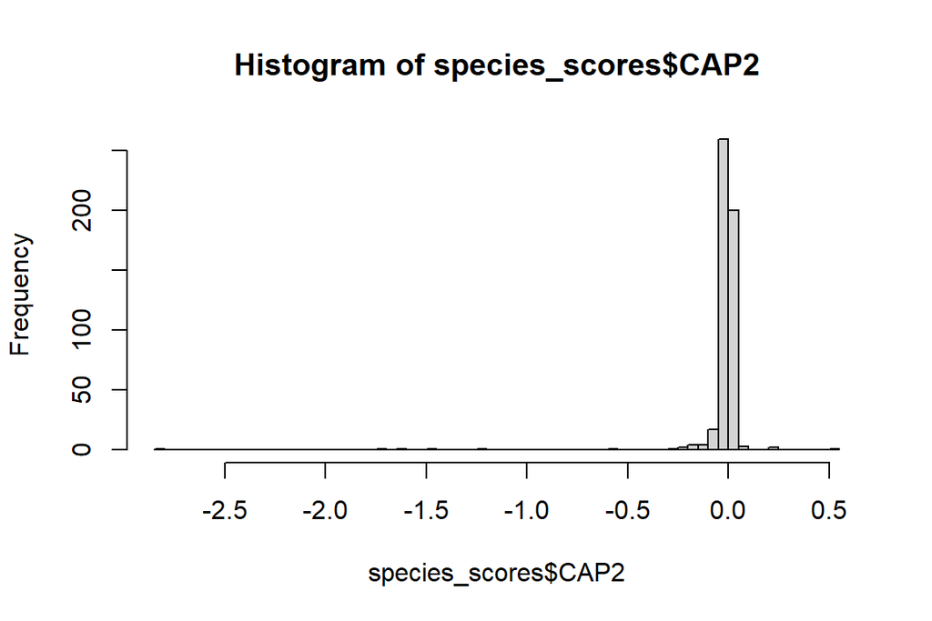

```r
hist(species_scores$CAP2, breaks = 50)
```

```r
summary(species_scores$CAP1)
```

```
##      Min.   1st Qu.    Median      Mean   3rd Qu.      Max.
## -7.010728 -0.000455  0.000018 -0.028936  0.000136  0.110956
```

```r
summary(species_scores$CAP2)
```

```
##       Min.    1st Qu.     Median       Mean    3rd Qu.       Max.
## -2.8140492 -0.0010509 -0.0000452 -0.0242252  0.0000738  0.5422269
```

```r
species_scores<-subset(species_scores, CAP1 < -1  | CAP2 > 0.2 | CAP2 < -0.2)

#species_scores$CAP1<-species_scores$CAP1*0.8
#species_scores$CAP2<-species_scores$CAP2*0.8



species_scores$ASV<-row.names(species_scores)

taxonomy<-data.frame(tax_table(scaled_core))
head(taxonomy)
```

|  | Kingdom | Phylum | Class | Order | Family | Genus | Species |
| --- | --- | --- | --- | --- | --- | --- | --- |
| a29558bc215cfe6f913afafef02450b9 | Bacteria | Proteobacteria | Gammaproteobacteria | Betaproteobacteriales | Rhodocyclaceae | Uliginosibacterium | NA |
| de14e4fbd65f5ea24336f74fca93998d | Bacteria | Proteobacteria | Gammaproteobacteria | Betaproteobacteriales | Rhodocyclaceae | Niveibacterium | NA |
| b1a40d7ca4ef789afb38c8de415893eb | Bacteria | Proteobacteria | Gammaproteobacteria | Betaproteobacteriales | Burkholderiaceae | Lautropia | NA |
| bd28d84ee5305bf27575469eb63ba948 | Bacteria | Proteobacteria | Gammaproteobacteria | Betaproteobacteriales | Procabacteriaceae | Procabacter | NA |
| eb5e72c0f85766e6bd0130723b04144c | Bacteria | Proteobacteria | Gammaproteobacteria | Betaproteobacteriales | Burkholderiaceae | Massilia | NA |
| c0f775fff77049501c4f8b4f5460097c | Bacteria | Proteobacteria | Gammaproteobacteria | Betaproteobacteriales | Burkholderiaceae | Cupriavidus | NA |

```r
taxonomy$ASV<-row.names(taxonomy)

species_scores<-merge(species_scores, taxonomy, by = "ASV")

subset(species_scores, Genus == "Lactococcus")
```

|  | ASV | CAP1 | CAP2 | Kingdom | Phylum | Class | Order | Family | Genus | Species |
| --- | --- | --- | --- | --- | --- | --- | --- | --- | --- | --- |
| 8 | b3d2cc3b9f0184830bec2ef73bcc6166 | -0.01112888 | 0.2194624 | Bacteria | Firmicutes | Bacilli | Lactobacillales | Streptococcaceae | Lactococcus | NA |

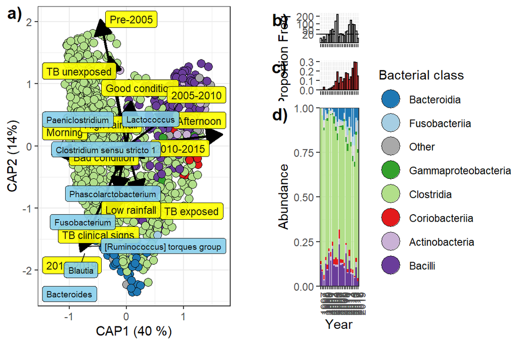

```r
#################

species_scores[4,2]<-species_scores[4,2]*0.2
species_scores[4,3]<-species_scores[4,3]*0.2


species_scores[5,2]<-species_scores[5,2]*0.8
species_scores[5,3]<-species_scores[5,3]*0.8


species_scores<-species_scores[-6,]

species_scores<-subset(species_scores,
                       Genus == "Clostridium sensu stricto 1" |
                         Genus == "Blautia" |
                         Genus == "Fusobacterium" |
                         Genus == "Bacteroides" |
                         Genus == "Phascolarctobacterium" |
                         Genus == "Lactococcus" |
                         Genus == "Paeniclostridium" |
                         Genus == "[Ruminococcus] torques group")

species_scores[6,3]<-species_scores[6,3]*0.8
species_scores[6,2]<-species_scores[6,2]*0.8

###################
###################
###################
###################


ord_plot<-ggplot(vectors_df, aes(x = CAP1, y = CAP2))+
  geom_point(aes(fill = DomClass_plot), pch = 21, size = 3)+
  scale_fill_manual(values = rev(pal))+
  theme_bw()+
  xlab("CAP1 (40 %)")+ylab("CAP2 (14%)")+
 guides(fill = guide_legend(override.aes = list(size = 7)))+
  labs(fill = "Bacterial class")+

  # add arrows

  geom_segment(data=centroids_df, aes(x = 0, y = 0, xend = CAP1*3, yend = CAP2*3),
    arrow = arrow(length = unit(0.5, "cm"), type = "closed"), lwd = 1,  col = "black")+
  ggrepel::geom_label_repel(data=centroids_df,
    alpha = 0.9, col = "black", size = 3, fill = "yellow",
    aes(CAP1 *3, CAP2*3, label = Label))+

  # add species
  geom_point(data = species_scores,  size = 4, col = "black", pch = 8, stroke = 0, alpha = 0)+
   ggrepel::geom_label_repel(data=species_scores,
    alpha = 0.9, col = "black", size = 2.5, fill = "skyblue",
    aes( label = Genus))



ggarrange(ord_plot,year_plot,  ncol = 2 , common.legend = T, legend = "right", widths = c(3.5,2), labels = c("a)", NA))
```

```r
#ggsave("Figures/Fig3.pdf")


#Saving 11.6 x 5.91 in image
```

This chunk took 0.14 minutes

# 10 Model genus level changes

### 10.0.1 Model year as a smoothed continuous variable

Make an ‘other’ category for rare taxa

```r
genus_ps<-tax_glom(meerkat_filtered, taxrank = "Genus")

genus_abundances_df<-data.frame(taxa_sums(genus_ps))

genus_abundances_df$ASV<-row.names(genus_abundances_df)

taxonomy<-data.frame(tax_table(genus_ps))
taxonomy$ASV<-row.names(taxonomy)


genus_abundances_df<-merge(genus_abundances_df, taxonomy, by = "ASV")
names(genus_abundances_df)[2]<-"Abundance"

genus_abundances_df<-genus_abundances_df %>% dplyr::arrange(-Abundance)

top_genera<- as.character(genus_abundances_df$ASV[1:30])

sample_data(genus_ps)<-sample_data(genus_ps)[,c( "feature.id")]

top_genera_melt<-psmelt(genus_ps)

# make a category for rare genera

top_genera_melt$Genus2<-ifelse(top_genera_melt$OTU %in% top_genera, top_genera_melt$Genus, "Rare taxa")


top_genera_melt2<-top_genera_melt %>% group_by(Sample, Genus2) %>% summarize(Abundance2 = sum(Abundance))


metadata<-data.frame(sample_data(meerkat_filtered))

top_genera_melt3<- merge(top_genera_melt2, metadata, by.x = "Sample", by.y = "feature.id")
names(top_genera_melt3)
```

```
##  [1] "Sample"              "Genus2"              "Abundance2"
##  [4] "IndividID"           "SampleDate"          "SampleTime"
##  [7] "Storage"             "Seq_run"             "Imtechella"
## [10] "Allobacillus"        "Seq_depth"           "scaling_factor"
## [13] "Seq_depth_nospikein" "BirthDate"           "DeathDate"
## [16] "AgeAtSampling"       "GroupAtSampling"     "Condition_weight"
## [19] "SocialStatus"        "Temp_max"            "sum_rainfall_month"
## [22] "HoursAfterSunrise"   "TimeCat"             "Year"
## [25] "month"               "Season"              "TB_status"
## [28] "TB_exposure"         "TB_resistance"       "TB_survival"
## [31] "TB_symptom_date"     "TB_exposure_date"    "TB_stage"
## [34] "TotalAbundance"
```

```r
head(top_genera_melt3)
```

|  | Sample | Genus2 | Abundance2 | IndividID | SampleDate | SampleTime | Storage | Seq_run | Imtechella | Allobacillus | Seq_depth | scaling_factor | Seq_depth_nospikein | BirthDate | DeathDate | AgeAtSampling | GroupAtSampling | Condition_weight | SocialStatus | Temp_max | sum_rainfall_month | HoursAfterSunrise | TimeCat | Year | month | Season | TB_status | TB_exposure | TB_resistance | … |
| --- | --- | --- | --- | --- | --- | --- | --- | --- | --- | --- | --- | --- | --- | --- | --- | --- | --- | --- | --- | --- | --- | --- | --- | --- | --- | --- | --- | --- | --- | --- |
| 1 | Feature1 | [Ruminococcus] torques group | 1068 | ID 69 | 1997-04-18 | 1899-12-30 08:29:00 | FROZEN | RUN1 | 247 | 331 | 27482 | 4.769479 | 26904 | 1997-03-03 | 2003-12-08 | 46 | Vivian | -101.9367 | Subordinate | 32.7 | 25.4 | 1.545278 | MORNING | 1997 | 4 | WET | Unexposed | NA | NA | … |
| 2 | Feature1 | Alloprevotella | 0 | ID 69 | 1997-04-18 | 1899-12-30 08:29:00 | FROZEN | RUN1 | 247 | 331 | 27482 | 4.769479 | 26904 | 1997-03-03 | 2003-12-08 | 46 | Vivian | -101.9367 | Subordinate | 32.7 | 25.4 | 1.545278 | MORNING | 1997 | 4 | WET | Unexposed | NA | NA | … |
| 3 | Feature1 | Bacillus | 0 | ID 69 | 1997-04-18 | 1899-12-30 08:29:00 | FROZEN | RUN1 | 247 | 331 | 27482 | 4.769479 | 26904 | 1997-03-03 | 2003-12-08 | 46 | Vivian | -101.9367 | Subordinate | 32.7 | 25.4 | 1.545278 | MORNING | 1997 | 4 | WET | Unexposed | NA | NA | … |
| 4 | Feature1 | Bacteroides | 0 | ID 69 | 1997-04-18 | 1899-12-30 08:29:00 | FROZEN | RUN1 | 247 | 331 | 27482 | 4.769479 | 26904 | 1997-03-03 | 2003-12-08 | 46 | Vivian | -101.9367 | Subordinate | 32.7 | 25.4 | 1.545278 | MORNING | 1997 | 4 | WET | Unexposed | NA | NA | … |
| 5 | Feature1 | Blautia | 27568 | ID 69 | 1997-04-18 | 1899-12-30 08:29:00 | FROZEN | RUN1 | 247 | 331 | 27482 | 4.769479 | 26904 | 1997-03-03 | 2003-12-08 | 46 | Vivian | -101.9367 | Subordinate | 32.7 | 25.4 | 1.545278 | MORNING | 1997 | 4 | WET | Unexposed | NA | NA | … |
| 6 | Feature1 | Catenisphaera | 377 | ID 69 | 1997-04-18 | 1899-12-30 08:29:00 | FROZEN | RUN1 | 247 | 331 | 27482 | 4.769479 | 26904 | 1997-03-03 | 2003-12-08 | 46 | Vivian | -101.9367 | Subordinate | 32.7 | 25.4 | 1.545278 | MORNING | 1997 | 4 | WET | Unexposed | NA | NA | … |

This chunk took 0.09 minutes